# White Wine Quality by Nita Awasthi

#### Data elements ( Number of Rows and columns, column names, summary of the data)

```
## [1] 4898
```

```
## [1] 13
```

```
##  [1] "X"                    "fixed.acidity"        "volatile.acidity"
##  [4] "citric.acid"          "residual.sugar"       "chlorides"
##  [7] "free.sulfur.dioxide"  "total.sulfur.dioxide" "density"
## [10] "pH"                   "sulphates"            "alcohol"
## [13] "quality"
```

```
##        X        fixed.acidity    volatile.acidity  citric.acid
##  Min.   :   1   Min.   : 3.800   Min.   :0.0800   Min.   :0.0000
##  1st Qu.:1225   1st Qu.: 6.300   1st Qu.:0.2100   1st Qu.:0.2700
##  Median :2450   Median : 6.800   Median :0.2600   Median :0.3200
##  Mean   :2450   Mean   : 6.855   Mean   :0.2782   Mean   :0.3342
##  3rd Qu.:3674   3rd Qu.: 7.300   3rd Qu.:0.3200   3rd Qu.:0.3900
##  Max.   :4898   Max.   :14.200   Max.   :1.1000   Max.   :1.6600
##  residual.sugar     chlorides       free.sulfur.dioxide
##  Min.   : 0.600   Min.   :0.00900   Min.   :  2.00
##  1st Qu.: 1.700   1st Qu.:0.03600   1st Qu.: 23.00
##  Median : 5.200   Median :0.04300   Median : 34.00
##  Mean   : 6.391   Mean   :0.04577   Mean   : 35.31
##  3rd Qu.: 9.900   3rd Qu.:0.05000   3rd Qu.: 46.00
##  Max.   :65.800   Max.   :0.34600   Max.   :289.00
##  total.sulfur.dioxide    density             pH          sulphates
##  Min.   :  9.0        Min.   :0.9871   Min.   :2.720   Min.   :0.2200
##  1st Qu.:108.0        1st Qu.:0.9917   1st Qu.:3.090   1st Qu.:0.4100
##  Median :134.0        Median :0.9937   Median :3.180   Median :0.4700
##  Mean   :138.4        Mean   :0.9940   Mean   :3.188   Mean   :0.4898
##  3rd Qu.:167.0        3rd Qu.:0.9961   3rd Qu.:3.280   3rd Qu.:0.5500
##  Max.   :440.0        Max.   :1.0390   Max.   :3.820   Max.   :1.0800
##     alcohol         quality
##  Min.   : 8.00   Min.   :3.000
##  1st Qu.: 9.50   1st Qu.:5.000
##  Median :10.40   Median :6.000
##  Mean   :10.51   Mean   :5.878
##  3rd Qu.:11.40   3rd Qu.:6.000
##  Max.   :14.20   Max.   :9.000
```

# Univariate Plots Section

Initial summary observations: Average white wine quality in this data set is about midway 5.8 (scale of 1-10).

Fixed acidity mean is 6.855 with values ranging from 3.8 - 14.2.

volatile acidity mean is 0.2782 with values ranging from 0.0800 - 1.1000.

citric acid mean is 0.33 with values ranging from 0.0 to 1.66.

Residual sugar mean is low at 6.391 but there are wines with high Sugar residual. Values range from 0.600 - 65.800.

chlorides mean is 0.04577 with values ranging from 0.009 - 0.346.

Free sulphur dioxide mean is 35.31 with values ranging from 2.00 - 289.00.

Total sulfur dioxide mean is 138.4 9.0 :440.0 (there seems to be a big range here).

There is not much variation in density with mean as 0.9940 and it ranges from 0.9871 - 1.039.

PH likewise is not much differance there , but since PH determine the acidic factor I would explore it a little to decide if it is a factor for wine quality. The mean is 3.188 and it ranges from 2.720 - 3.820.

The mean of sulphates is 0.4898 and it ranges from 0.22 - 1.08.

Alcohol level mean is 10.51 and it ranges from 8.00 - 14.20.

#### White Wine Quality (Table - Plot)

```
##
##    3    4    5    6    7    8    9
##   20  163 1457 2198  880  175    5
```

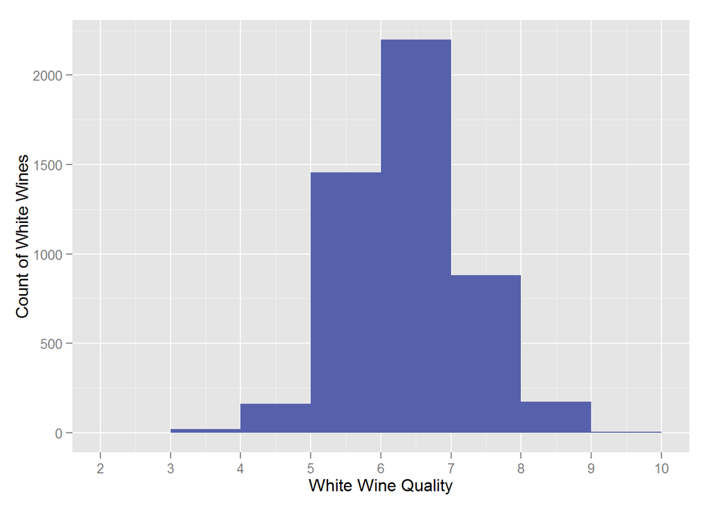

The plot indicates most wine in this data falls in the mid range quality of 5 - 6. There was no need transform the data for this plot as the data was pretty clear.

#### White Wine Fixed Acidity (Table - summary by quality - plot)

```
##
##  3.8  3.9  4.2  4.4  4.5  4.6  4.7  4.8  4.9    5  5.1  5.2  5.3  5.4  5.5
##    1    1    2    3    1    1    5    9    7   24   23   28   27   28   31
##  5.6  5.7  5.8  5.9    6  6.1 6.15  6.2  6.3  6.4 6.45  6.5  6.6  6.7  6.8
##   71   88  121  103  184  155    2  192  188  280    1  225  290  236  308
##  6.9    7  7.1 7.15  7.2  7.3  7.4  7.5  7.6  7.7  7.8  7.9    8  8.1  8.2
##  241  232  200    2  206  178  194  123  153   93   93   74   80   56   56
##  8.3  8.4  8.5  8.6  8.7  8.8  8.9    9  9.1  9.2  9.3  9.4  9.5  9.6  9.7
##   52   35   32   25   15   18   16   17    6   21    3   11    2    5    4
##  9.8  9.9   10 10.2 10.3 10.7 11.8 14.2
##    8    2    3    1    2    2    1    1
```

```
## whiteWineQuality$quality: 3
##    Min. 1st Qu.  Median    Mean 3rd Qu.    Max.
##   4.200   6.575   7.300   7.600   8.525  11.800
## --------------------------------------------------------
## whiteWineQuality$quality: 4
##    Min. 1st Qu.  Median    Mean 3rd Qu.    Max.
##   4.800   6.400   6.900   7.129   7.600  10.200
## --------------------------------------------------------
## whiteWineQuality$quality: 5
##    Min. 1st Qu.  Median    Mean 3rd Qu.    Max.
##   4.500   6.400   6.800   6.934   7.400  10.300
## --------------------------------------------------------
## whiteWineQuality$quality: 6
##    Min. 1st Qu.  Median    Mean 3rd Qu.    Max.
##   3.800   6.300   6.800   6.838   7.300  14.200
## --------------------------------------------------------
## whiteWineQuality$quality: 7
##    Min. 1st Qu.  Median    Mean 3rd Qu.    Max.
##   4.200   6.200   6.700   6.735   7.200   9.200
## --------------------------------------------------------
## whiteWineQuality$quality: 8
##    Min. 1st Qu.  Median    Mean 3rd Qu.    Max.
##   3.900   6.200   6.800   6.657   7.300   8.200
## --------------------------------------------------------
## whiteWineQuality$quality: 9
##    Min. 1st Qu.  Median    Mean 3rd Qu.    Max.
##    6.60    6.90    7.10    7.42    7.40    9.10
```

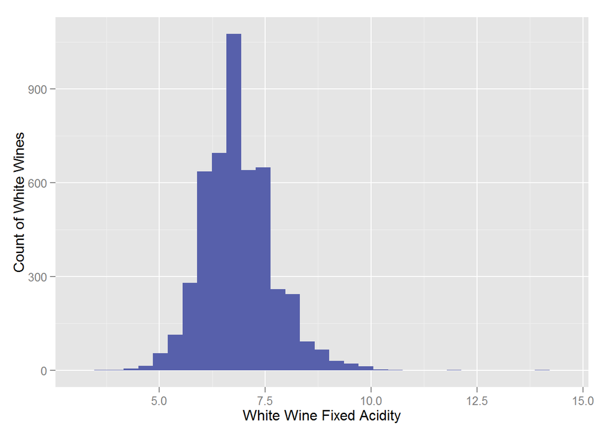

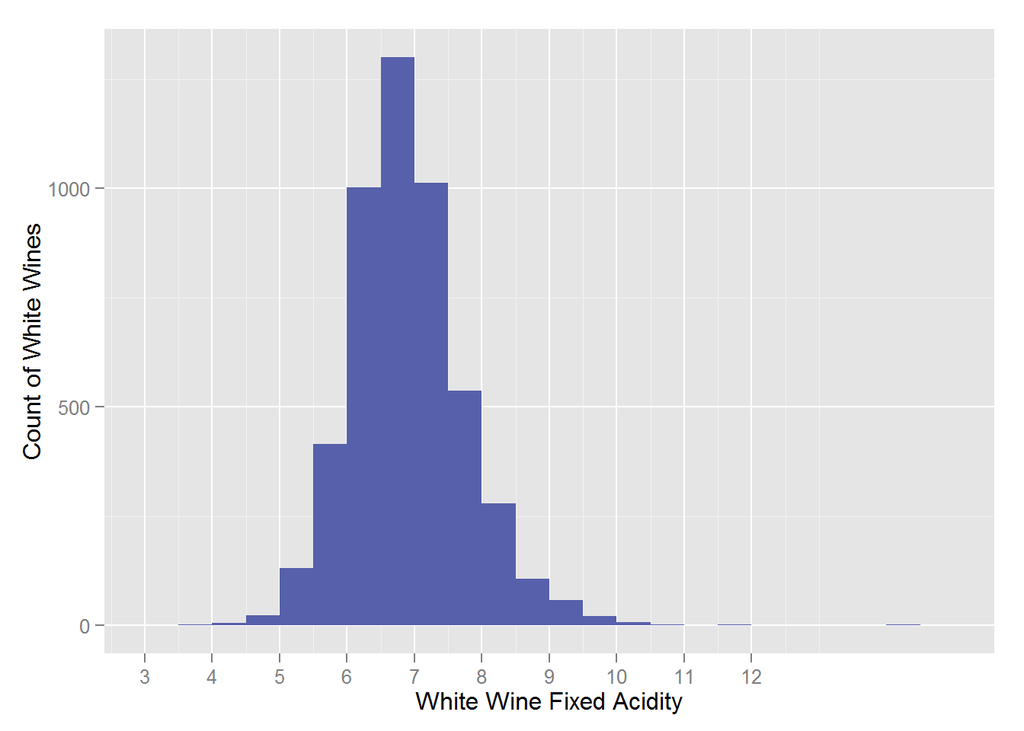

The initial plot and data indicated most of the data ranged from around 3 - 10 with some outliers at 15. Limiting the value to 12 gives a better plot and tells us most of the wine fixed acidity is at around 6.5

#### White Wine Volatile Acidity( table - summary by wine quality - plot)

```
##
##  0.08 0.085  0.09   0.1 0.105  0.11 0.115  0.12 0.125  0.13 0.135  0.14
##     4     1     1     6     6    13     3    34     3    44     1    56
## 0.145  0.15 0.155  0.16 0.165  0.17 0.175  0.18 0.185  0.19   0.2 0.205
##     4    88     5   141     2   140     1   177     5   170   214     4
##  0.21 0.215  0.22 0.225  0.23 0.235  0.24 0.245  0.25 0.255  0.26 0.265
##   191     1   229     4   216     4   253     4   231    10   240     5
##  0.27 0.275  0.28 0.285  0.29 0.295   0.3 0.305  0.31 0.315  0.32 0.325
##   218     3   263     5   160     3   198     4   148     4   182     2
##  0.33 0.335  0.34 0.345  0.35 0.355  0.36 0.365  0.37 0.375  0.38 0.385
##   134     7   135     9    86     1   104     2    65     2    63     2
##  0.39 0.395   0.4 0.405  0.41 0.415  0.42 0.425  0.43 0.435  0.44 0.445
##    61     2    59     1    54     4    36     2    35     2    46     4
##  0.45 0.455  0.46  0.47 0.475  0.48 0.485  0.49 0.495   0.5  0.51  0.52
##    25     2    30    15     3    17     3    14     2    14    10    10
##  0.53  0.54 0.545  0.55 0.555  0.56  0.57  0.58 0.585  0.59 0.595   0.6
##     8    10     1    14     2     9     4     7     2     4     2     7
##  0.61 0.615  0.62  0.63  0.64  0.65 0.655  0.66  0.67  0.68 0.685  0.69
##     7     4     5     2     7     2     3     4     5     3     1     2
## 0.695 0.705  0.71  0.73  0.74  0.75  0.76  0.78 0.785 0.815  0.85 0.905
##     3     2     1     1     1     1     2     1     1     1     1     1
##  0.91  0.93 0.965 1.005   1.1
##     1     1     1     1     1
```

```
## whiteWineQuality$quality: 3
##    Min. 1st Qu.  Median    Mean 3rd Qu.    Max.
##  0.1700  0.2375  0.2600  0.3332  0.4125  0.6400
## --------------------------------------------------------
## whiteWineQuality$quality: 4
##    Min. 1st Qu.  Median    Mean 3rd Qu.    Max.
##  0.1100  0.2700  0.3200  0.3812  0.4600  1.1000
## --------------------------------------------------------
## whiteWineQuality$quality: 5
##    Min. 1st Qu.  Median    Mean 3rd Qu.    Max.
##   0.100   0.240   0.280   0.302   0.340   0.905
## --------------------------------------------------------
## whiteWineQuality$quality: 6
##    Min. 1st Qu.  Median    Mean 3rd Qu.    Max.
##  0.0800  0.2000  0.2500  0.2606  0.3000  0.9650
## --------------------------------------------------------
## whiteWineQuality$quality: 7
##    Min. 1st Qu.  Median    Mean 3rd Qu.    Max.
##  0.0800  0.1900  0.2500  0.2628  0.3200  0.7600
## --------------------------------------------------------
## whiteWineQuality$quality: 8
##    Min. 1st Qu.  Median    Mean 3rd Qu.    Max.
##  0.1200  0.2000  0.2600  0.2774  0.3300  0.6600
## --------------------------------------------------------
## whiteWineQuality$quality: 9
##    Min. 1st Qu.  Median    Mean 3rd Qu.    Max.
##   0.240   0.260   0.270   0.298   0.360   0.360
```

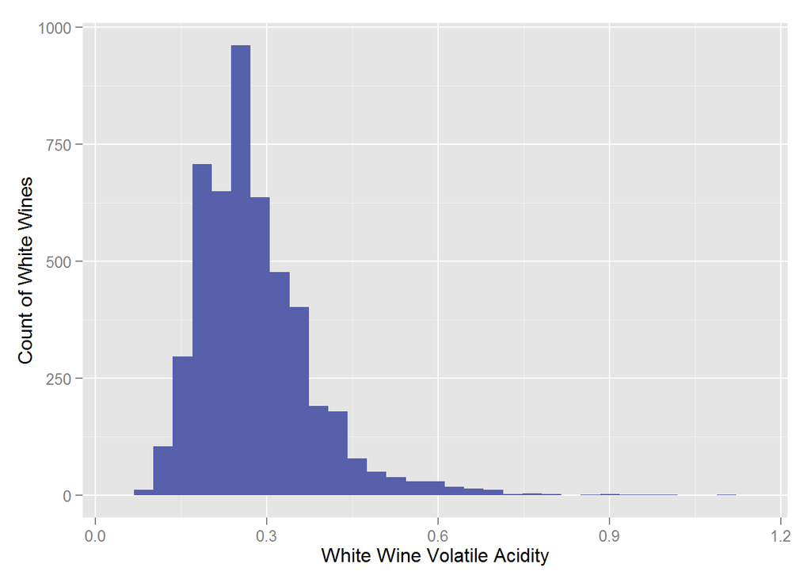

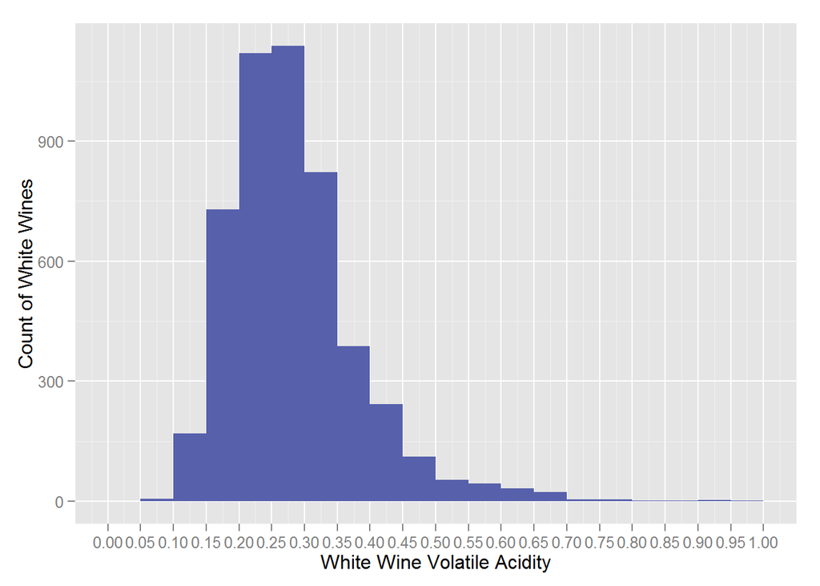

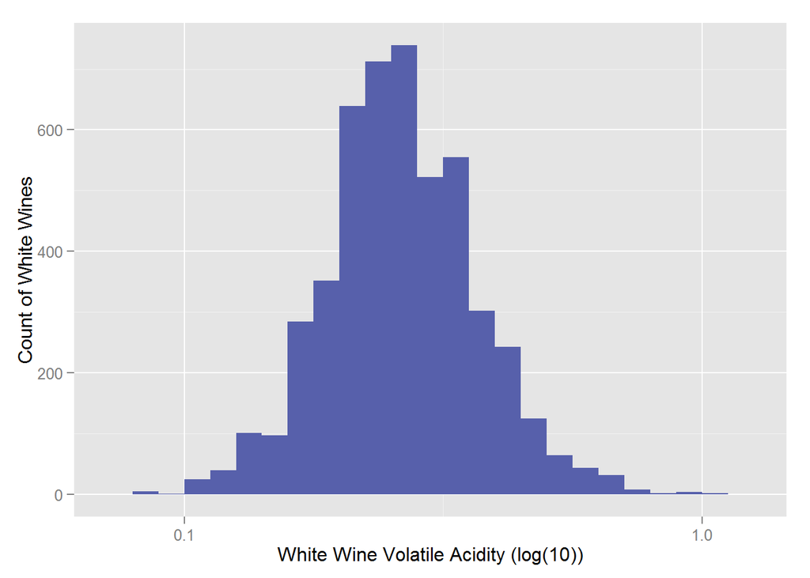

The plot of volatile acidity is a long tailed one skewed to the right. Adjusting the limits and adding breaks gave similar result. For this value I created log10 plot to reduce the skewedness.

#### White Wine Alcohol level (plot - summary by quality - plots)

```
##
##           8         8.4         8.5         8.6         8.7         8.8
##           2           3           9          23          78         107
##         8.9           9         9.1         9.2         9.3         9.4
##          95         185         144         199         134         229
##         9.5 9.533333333        9.55         9.6 9.633333333         9.7
##         228           3           2         128           1         105
## 9.733333333        9.75         9.8         9.9          10 10.03333333
##           2           1         136         109         162           1
##        10.1 10.13333333       10.15        10.2        10.3        10.4
##         114           2           3         130          85         153
## 10.46666667        10.5 10.53333333       10.55 10.56666667        10.6
##           2         160           1           2           1         114
##       10.65        10.7        10.8        10.9 10.93333333 10.96666667
##           1          96         135          88           2           3
##       10.98          11       11.05 11.06666667        11.1        11.2
##           1         158           2           1          83         112
## 11.26666667        11.3 11.33333333       11.35 11.36666667        11.4
##           1         101           3           1           1         121
## 11.43333333       11.45 11.46666667        11.5       11.55        11.6
##           1           4           1          88           1          46
## 11.63333333       11.65        11.7 11.73333333       11.75        11.8
##           2           1          58           1           2          60
##       11.85        11.9       11.94       11.95          12       12.05
##           1          53           2           1         102           1
## 12.06666667        12.1       12.15        12.2       12.25        12.3
##           1          51           2          86           1          62
## 12.33333333        12.4        12.5        12.6        12.7       12.75
##           1          68          83          63          56           3
##        12.8 12.89333333        12.9          13       13.05        13.1
##          54           2          39          36           1          18
## 13.13333333        13.2        13.3        13.4        13.5       13.55
##           1          14           7          20          12           1
##        13.6        13.7        13.8        13.9          14       14.05
##           9           7           2           3           5           1
##        14.2
##           1
```

```
## whiteWineQuality$quality: 3
##    Min. 1st Qu.  Median    Mean 3rd Qu.    Max.
##    8.00    9.55   10.45   10.34   11.00   12.60
## --------------------------------------------------------
## whiteWineQuality$quality: 4
##    Min. 1st Qu.  Median    Mean 3rd Qu.    Max.
##    8.40    9.40   10.10   10.15   10.75   13.50
## --------------------------------------------------------
## whiteWineQuality$quality: 5
##    Min. 1st Qu.  Median    Mean 3rd Qu.    Max.
##   8.000   9.200   9.500   9.809  10.300  13.600
## --------------------------------------------------------
## whiteWineQuality$quality: 6
##    Min. 1st Qu.  Median    Mean 3rd Qu.    Max.
##    8.50    9.60   10.50   10.58   11.40   14.00
## --------------------------------------------------------
## whiteWineQuality$quality: 7
##    Min. 1st Qu.  Median    Mean 3rd Qu.    Max.
##    8.60   10.60   11.40   11.37   12.30   14.20
## --------------------------------------------------------
## whiteWineQuality$quality: 8
##    Min. 1st Qu.  Median    Mean 3rd Qu.    Max.
##    8.50   11.00   12.00   11.64   12.60   14.00
## --------------------------------------------------------
## whiteWineQuality$quality: 9
##    Min. 1st Qu.  Median    Mean 3rd Qu.    Max.
##   10.40   12.40   12.50   12.18   12.70   12.90
```

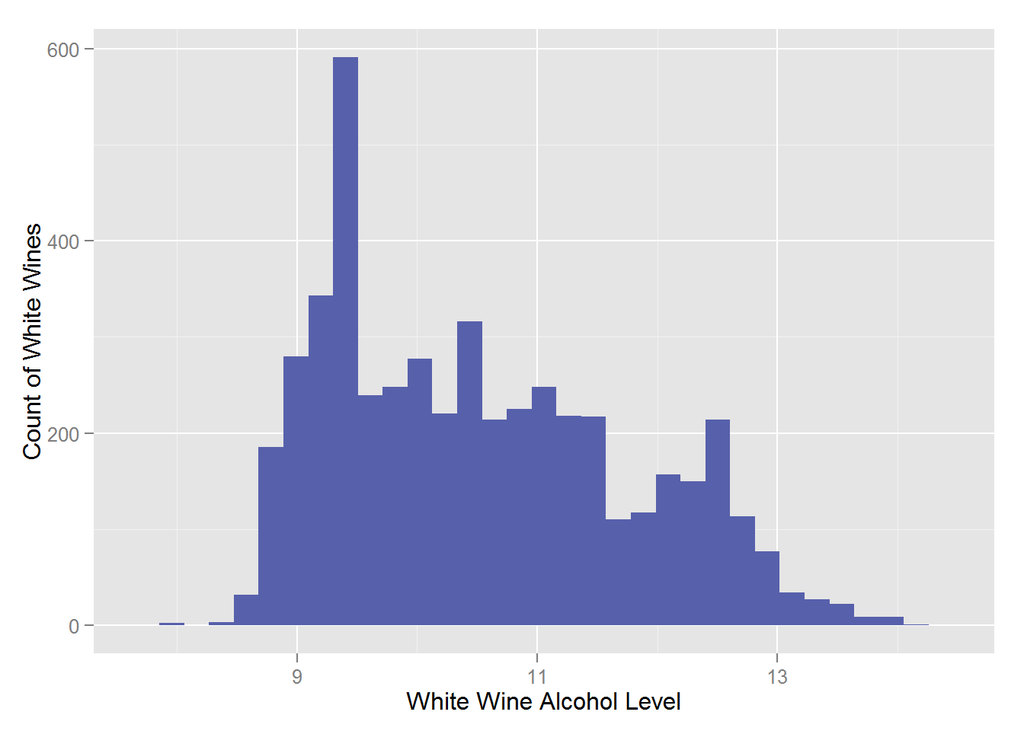

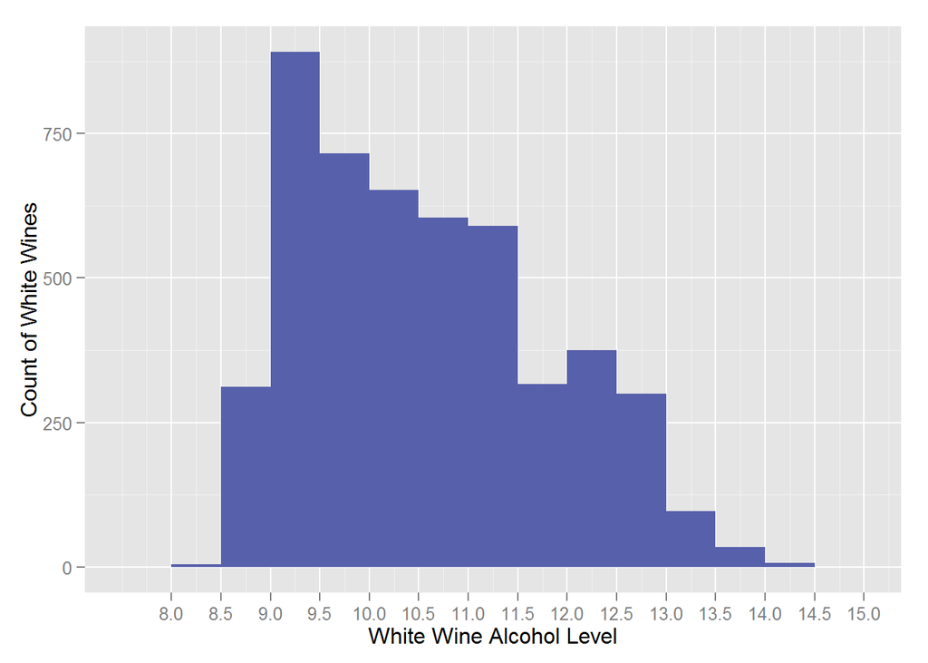

There is a varied range of values for alcohol level for wine most of them ranging from 8.5 to 12.5.

#### White Wine Residual Sugar (Table - summary by quality - plots)

```
##
##   0.6   0.7   0.8   0.9  0.95     1  1.05   1.1  1.15   1.2  1.25   1.3
##     2     7    25    39     4    93     1   146     3   187     3   147
##  1.35   1.4  1.45   1.5  1.55   1.6  1.65   1.7  1.75   1.8  1.85   1.9
##     2   184     4   142     2   165     2    99     1    99     3    59
##  1.95     2  2.05   2.1   2.2  2.25   2.3  2.35   2.4   2.5   2.6  2.65
##     2    79     1    51    56     2    42     1    41    40    33     1
##   2.7   2.8  2.85   2.9     3   3.1  3.15   3.2   3.3   3.4   3.5   3.6
##    38    36     1    25    17    17     1    28    23    13    31    22
##   3.7  3.75   3.8  3.85   3.9  3.95     4   4.1   4.2  4.25   4.3  4.35
##    12     2    21     3    17     3    19    17    31     2    19     1
##   4.4  4.45   4.5  4.55   4.6   4.7  4.75   4.8  4.85   4.9     5   5.1
##    14     3    33     2    40    29     5    38     1    35    43    28
##  5.15   5.2  5.25   5.3  5.35   5.4  5.45   5.5  5.55   5.6   5.7   5.8
##     2    29     4    17     2    23     2    13     1    16    30    23
##  5.85   5.9  5.95     6   6.1   6.2   6.3  6.35   6.4   6.5  6.55   6.6
##     2    19     1    23    21    31    39     1    34    26     1    30
##  6.65   6.7  6.75   6.8  6.85   6.9  6.95     7  7.05   7.1   7.2  7.25
##     3    25     1    28     6    20     1    31     2    36    29     2
##   7.3  7.35   7.4  7.45   7.5   7.6   7.7  7.75   7.8  7.85   7.9  7.95
##    19     2    40     1    30    29    34     2    41     1    32     1
##     8   8.1  8.15   8.2  8.25   8.3   8.4  8.45   8.5  8.55   8.6  8.65
##    32    34     1    36     2    31    13     1    24     1    27     1
##   8.7  8.75   8.8   8.9  8.95     9  9.05   9.1  9.15   9.2  9.25   9.3
##    18     2    22    23     1    18     1    17     2    22     2    11
##   9.4   9.5  9.55   9.6  9.65   9.7   9.8  9.85   9.9    10 10.05  10.1
##    10     9     1    18     4    22    16     3    18    18     3    14
##  10.2  10.3  10.4  10.5 10.55  10.6 10.65  10.7  10.8  10.9    11  11.1
##    23    16    25    16     1    22     1    26    17    11    19    18
##  11.2 11.25  11.3  11.4 11.45  11.5  11.6  11.7 11.75  11.8  11.9 11.95
##    18     2    12    14     1    11    15     8     4    35    16     3
##    12 12.05  12.1 12.15  12.2  12.3  12.4  12.5 12.55  12.6  12.7 12.75
##    16     1    21     4    15    13    19    16     2    16    16     1
##  12.8 12.85  12.9    13  13.1 13.15  13.2  13.3  13.4  13.5 13.55  13.6
##    25     4    25    19    23     1    13    16     7    10     3    12
## 13.65  13.7  13.8  13.9    14 14.05  14.1 14.15  14.2  14.3 14.35  14.4
##     4    21     8    18    16     1     4     1    20    17     3    17
## 14.45  14.5 14.55  14.6  14.7 14.75  14.8  14.9 14.95    15  15.1 15.15
##     3    17     3    13    14     2    12    14     2    13     7     1
##  15.2 15.25  15.3  15.4  15.5 15.55  15.6  15.7 15.75  15.8  15.9    16
##     6     1     9    17    11     6    14     9     1     6     2    10
## 16.05  16.1  16.2  16.3  16.4 16.45  16.5 16.55  16.6 16.65  16.7 16.75
##     6     2     7     7     5     1     3     1     2     5     5     2
##  16.8 16.85  16.9 16.95    17 17.05  17.1  17.2  17.3 17.35  17.4 17.45
##     4     4     3     3     1     1     5     9    14     1     2     2
##  17.5 17.55  17.6  17.7 17.75  17.8 17.85  17.9 17.95    18 18.05  18.1
##     8     3     2     1     4    13     5     2     3     2     3     6
## 18.15  18.2  18.3 18.35  18.4  18.5  18.6 18.75  18.8  18.9 18.95  19.1
##     8     3     2     4     1     1     1     4     3     1     3     1
## 19.25  19.3 19.35  19.4 19.45  19.5  19.6  19.8  19.9 19.95 20.15  20.2
##     3     4     1     2     3     2     1     4     1     3     1     2
##  20.3  20.4  20.7  20.8    22  22.6  23.5 26.05  31.6  65.8
##     1     1     2     2     2     1     1     2     2     1
```

```
## whiteWineQuality$quality: 3
##    Min. 1st Qu.  Median    Mean 3rd Qu.    Max.
##   0.700   1.588   4.600   6.392  10.700  16.200
## --------------------------------------------------------
## whiteWineQuality$quality: 4
##    Min. 1st Qu.  Median    Mean 3rd Qu.    Max.
##   0.700   1.300   2.500   4.628   7.100  17.550
## --------------------------------------------------------
## whiteWineQuality$quality: 5
##    Min. 1st Qu.  Median    Mean 3rd Qu.    Max.
##   0.600   1.800   7.000   7.335  11.500  23.500
## --------------------------------------------------------
## whiteWineQuality$quality: 6
##    Min. 1st Qu.  Median    Mean 3rd Qu.    Max.
##   0.700   1.700   5.300   6.442   9.900  65.800
## --------------------------------------------------------
## whiteWineQuality$quality: 7
##    Min. 1st Qu.  Median    Mean 3rd Qu.    Max.
##   0.900   1.700   3.650   5.186   7.325  19.250
## --------------------------------------------------------
## whiteWineQuality$quality: 8
##    Min. 1st Qu.  Median    Mean 3rd Qu.    Max.
##   0.800   2.100   4.300   5.671   8.200  14.800
## --------------------------------------------------------
## whiteWineQuality$quality: 9
##    Min. 1st Qu.  Median    Mean 3rd Qu.    Max.
##    1.60    2.00    2.20    4.12    4.20   10.60
```

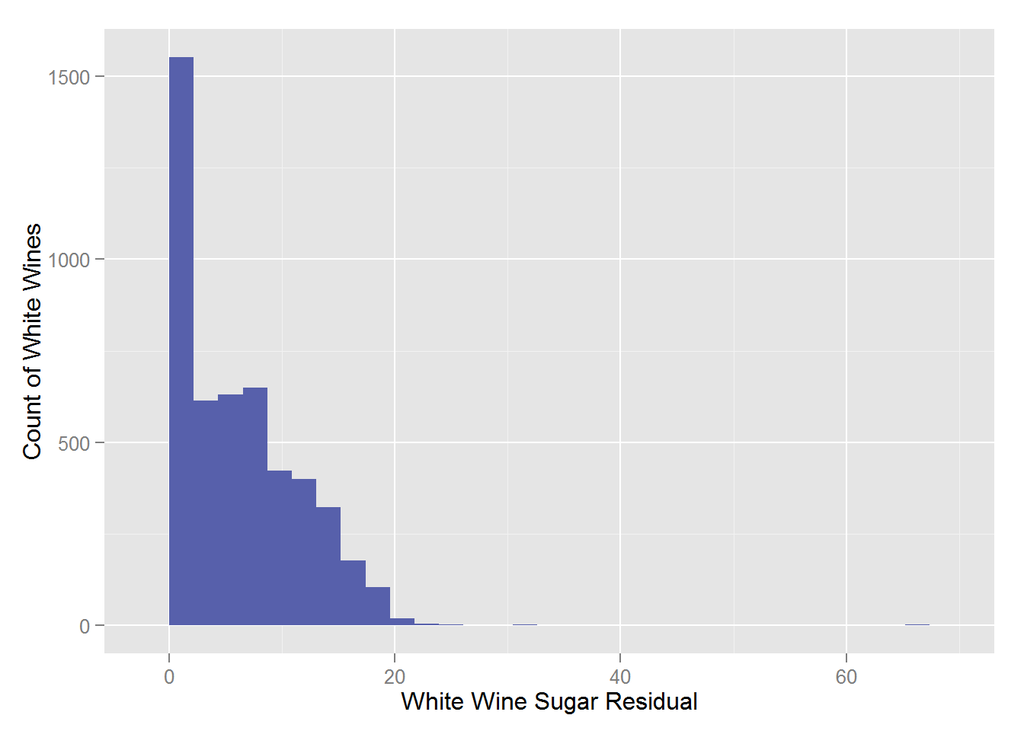

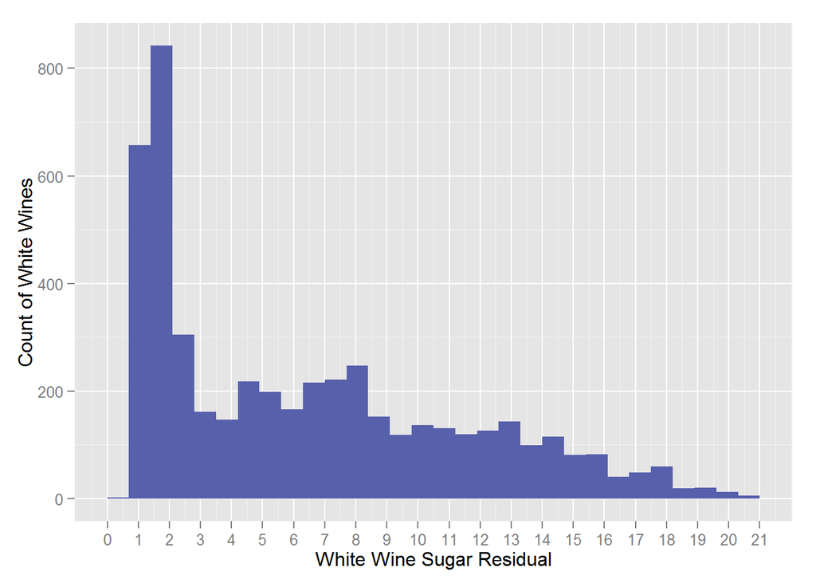

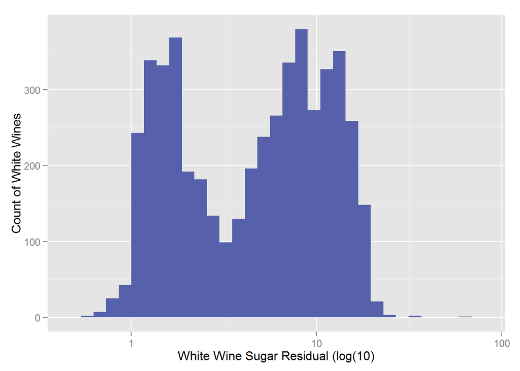

The initial plot for sugar is not very clear. It seems that is long tailed plot skewed to the right. Adding limits and breaks gives a better plot of distrbution of the sugar residual in data and it indicates the long tailed characteristic more clearing. Plotting a log10 plot gives a bimodal plot.

#### White Wine Free Sulfur Dioxide (Table, summary by quality, plots)

```
##
##     2     3     4     5     6     7     8     9    10    11  11.5    12
##     1    10    11    25    32    25    35    29    55    45     1    51
##    13    14    15  15.5    16    17    18    19  19.5    20    21    22
##    55    68    79     1    58    89    80    84     1   101    93   102
##    23  23.5    24    25    26    27    28  28.5    29    30  30.5    31
##   110     1   118   111   129    99   112     1   160    99     1   132
##    32    33    34    35  35.5    36    37    38  38.5    39  39.5    40
##   109   112   128   129     2   127   111   102     1    89     1   103
##  40.5    41  41.5    42  42.5    43  43.5    44  44.5    45    46    47
##     1   104     2    86     1    63     1    75     4   101    64    91
##    48  48.5    49    50  50.5    51  51.5    52  52.5    53    54    55
##    66     7    82    64     2    54     1    72     4    68    61    58
##    56    57    58    59  59.5    60  60.5    61  61.5    62    63    64
##    42    44    37    39     2    38     2    47     1    29    30    23
##  64.5    65    66    67    68    69    70  70.5    71    72    73  73.5
##     1    14    17    22    24    17    11     1     5     6     8     4
##    74    75    76    77  77.5    78    79  79.5    80    81    82  82.5
##     5     7     5     5     1     4     2     4     1     7     2     1
##    83    85    86    87    88    89    93    95    96    97    98   101
##     4     2     2     4     1     1     1     1     3     1     3     2
##   105   108   110   112 118.5 122.5   124   128   131 138.5 146.5   289
##     2     3     1     1     1     1     1     1     1     1     1     1
```

```
## whiteWineQuality$quality: 3
##    Min. 1st Qu.  Median    Mean 3rd Qu.    Max.
##    5.00   13.25   33.50   53.32   47.50  289.00
## --------------------------------------------------------
## whiteWineQuality$quality: 4
##    Min. 1st Qu.  Median    Mean 3rd Qu.    Max.
##    3.00    9.00   18.00   23.36   30.50  138.50
## --------------------------------------------------------
## whiteWineQuality$quality: 5
##    Min. 1st Qu.  Median    Mean 3rd Qu.    Max.
##    2.00   22.00   35.00   36.43   50.00  131.00
## --------------------------------------------------------
## whiteWineQuality$quality: 6
##    Min. 1st Qu.  Median    Mean 3rd Qu.    Max.
##    3.00   24.00   34.00   35.65   46.00  112.00
## --------------------------------------------------------
## whiteWineQuality$quality: 7
##    Min. 1st Qu.  Median    Mean 3rd Qu.    Max.
##    5.00   25.00   33.00   34.13   41.00  108.00
## --------------------------------------------------------
## whiteWineQuality$quality: 8
##    Min. 1st Qu.  Median    Mean 3rd Qu.    Max.
##    6.00   28.00   35.00   36.72   44.50  105.00
## --------------------------------------------------------
## whiteWineQuality$quality: 9
##    Min. 1st Qu.  Median    Mean 3rd Qu.    Max.
##    24.0    27.0    28.0    33.4    31.0    57.0
```

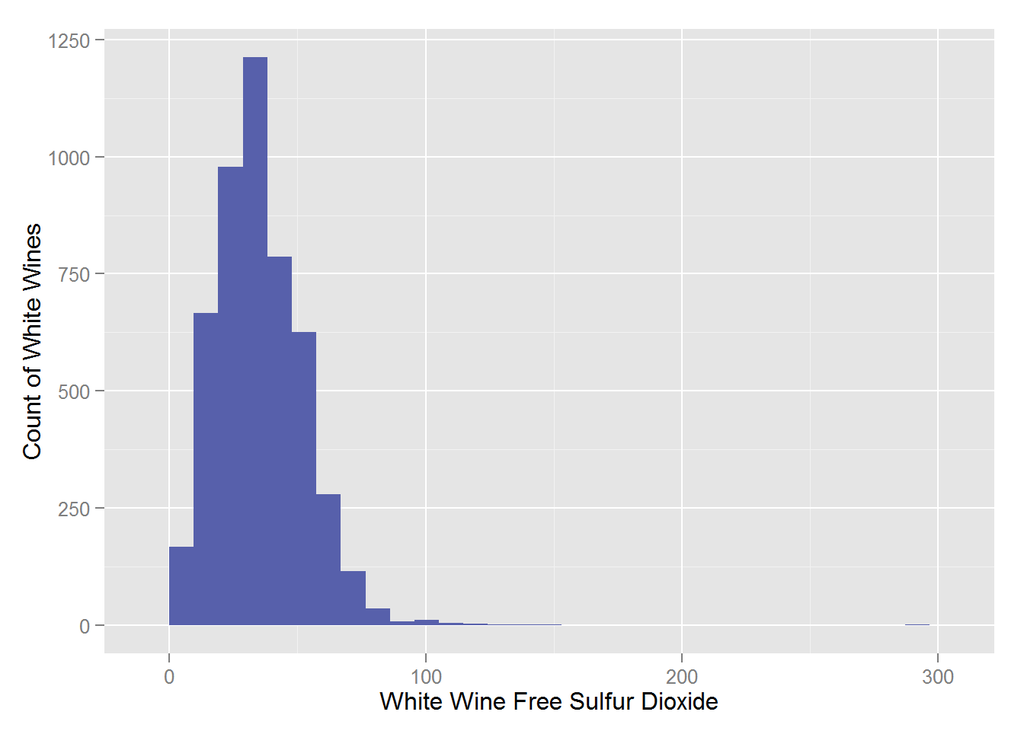

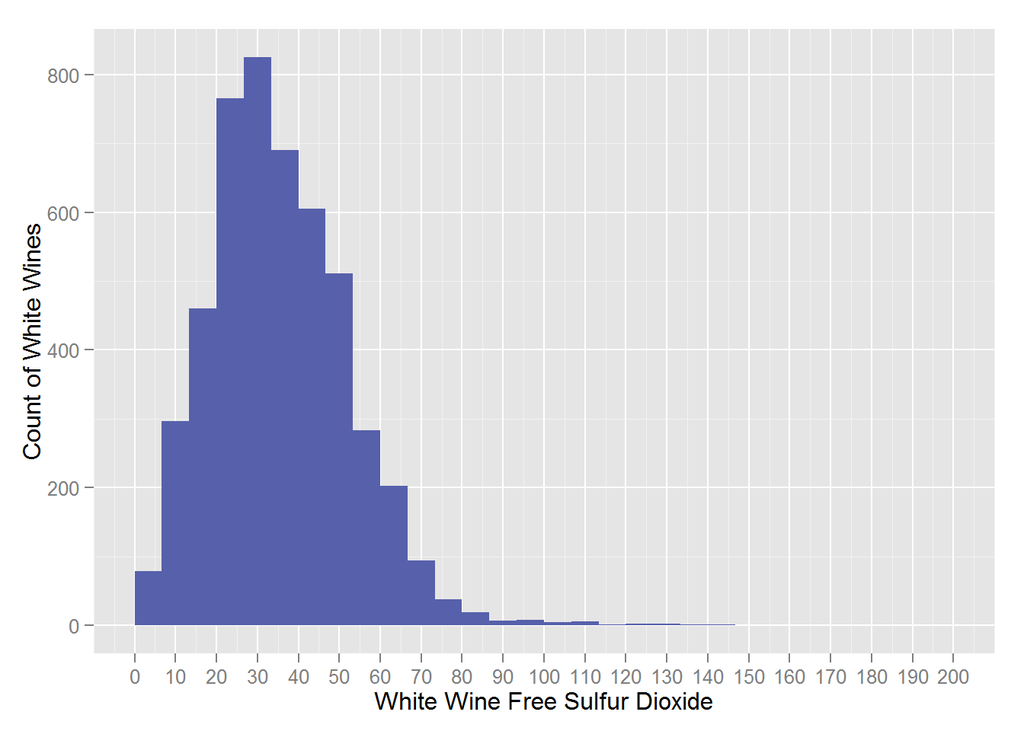

The first plot indicates there is some skewness in the data.Adding the limit to the plot does indicates it but there are also some outliers here but most of the data is between 10 - 70

#### White Wine Total Sulfur Dioxide (Table- summary by quality - plots)

```
##
##     9    10    18    19    21    24    25    26    28    29    30    31
##     1     1     2     1     1     3     1     1     4     2     2     1
##    33    34    37    40    41    44    45    46    47    48    49    50
##     1     2     3     3     4     1     2     2     3     1     4     3
##    51    53    54    55    56    57    58    59    60    61    62    63
##     3     2     2     7     5     7     2     5     6     9     2    10
##    64    65    66    67    68    69    70    71    72    73    74    75
##     6     8     7    12    14    10     8    12    17    20    12    14
##    76    77    78    79    80    81    82    83    84    85    86    87
##    26    14    17    15    23    21    17    17    27    20    25    39
##    88    89    90    91    92    93    94    95    96    97    98    99
##    15    23    30    22    30    42    28    34    28    41    49    34
##   100   101   102   103   104   105   106   107   108   109   110   111
##    37    47    37    34    44    41    32    45    32    37    47    69
```

[output cut: 28 more lines]

```
## whiteWineQuality$quality: 3
##    Min. 1st Qu.  Median    Mean 3rd Qu.    Max.
##    19.0   105.8   159.5   170.6   210.0   440.0
## --------------------------------------------------------
## whiteWineQuality$quality: 4
##    Min. 1st Qu.  Median    Mean 3rd Qu.    Max.
##    10.0    85.0   117.0   125.3   171.5   272.0
## --------------------------------------------------------
## whiteWineQuality$quality: 5
##    Min. 1st Qu.  Median    Mean 3rd Qu.    Max.
##     9.0   121.0   151.0   150.9   182.0   344.0
## --------------------------------------------------------
## whiteWineQuality$quality: 6
##    Min. 1st Qu.  Median    Mean 3rd Qu.    Max.
##    18.0   107.2   132.0   137.0   164.0   294.0
## --------------------------------------------------------
## whiteWineQuality$quality: 7
##    Min. 1st Qu.  Median    Mean 3rd Qu.    Max.
##    34.0   101.0   122.0   125.1   144.2   229.0
## --------------------------------------------------------
## whiteWineQuality$quality: 8
##    Min. 1st Qu.  Median    Mean 3rd Qu.    Max.
##    59.0   102.5   122.0   126.2   150.0   212.5
## --------------------------------------------------------
## whiteWineQuality$quality: 9
##    Min. 1st Qu.  Median    Mean 3rd Qu.    Max.
##      85     113     119     116     124     139
```

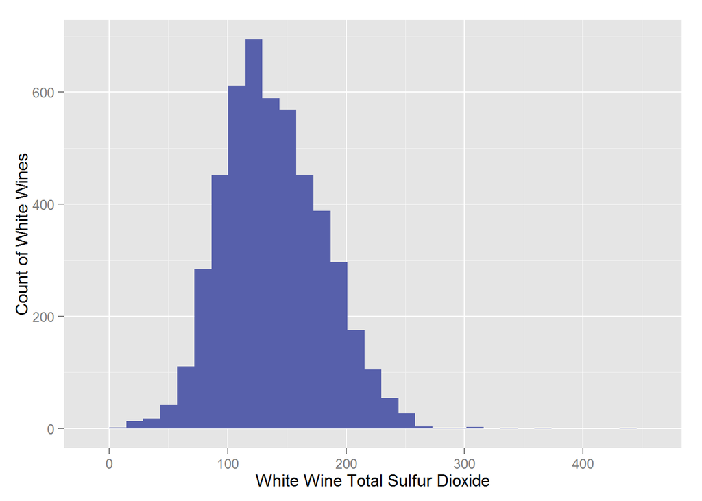

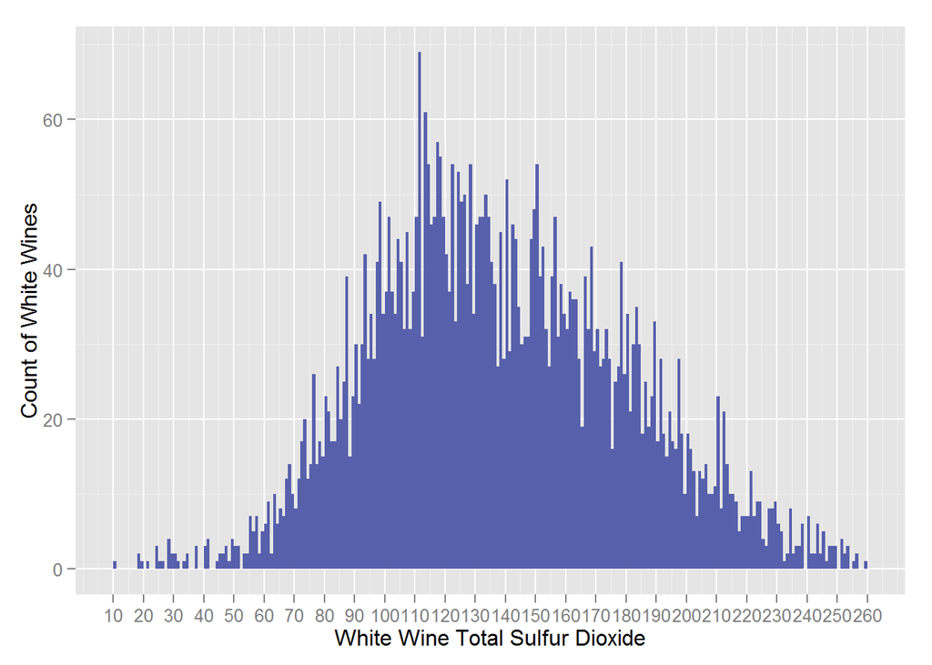

The first plot without any limits indicated a bell shaped plot with few outliers. However when the limit was added with breaks it indicated the variedness of the data.

#### White Wine PH levels (Table- Summary by quality - plots)

```
##
## 2.72 2.74 2.77 2.79  2.8 2.82 2.83 2.84 2.85 2.86 2.87 2.88 2.89  2.9 2.91
##    1    1    1    3    3    1    4    1    9    9    9   11   17   31   15
## 2.92 2.93 2.94 2.95 2.96 2.97 2.98 2.99    3 3.01 3.02 3.03 3.04 3.05 3.06
##   18   38   35   26   63   32   41   68   74   49   68   78   97   89  115
## 3.07 3.08 3.09  3.1 3.11 3.12 3.13 3.14 3.15 3.16 3.17 3.18 3.19  3.2 3.21
##   79  136   92  135  126  134  117  172  136  164  124  138  145  137   95
## 3.22 3.23 3.24 3.25 3.26 3.27 3.28 3.29  3.3 3.31 3.32 3.33 3.34 3.35 3.36
##  146  116  132  114   96   88   87   82   93   79   86   49   79   48   83
## 3.37 3.38 3.39  3.4 3.41 3.42 3.43 3.44 3.45 3.46 3.47 3.48 3.49  3.5 3.51
##   49   58   40   39   30   48   20   33   17   28   21   21   23   15   14
## 3.52 3.53 3.54 3.55 3.56 3.57 3.58 3.59  3.6 3.61 3.62 3.63 3.64 3.65 3.66
##   17   13   14    9    8    5    5    6    7    3    1    6    2    4    5
## 3.67 3.68 3.69  3.7 3.72 3.74 3.75 3.76 3.77 3.79  3.8 3.81 3.82
##    1    2    2    1    3    2    2    2    2    1    2    1    1
```

```
## whiteWineQuality$quality: 3
##    Min. 1st Qu.  Median    Mean 3rd Qu.    Max.
##   2.870   3.035   3.215   3.188   3.325   3.550
## --------------------------------------------------------
## whiteWineQuality$quality: 4
##    Min. 1st Qu.  Median    Mean 3rd Qu.    Max.
##   2.830   3.070   3.160   3.183   3.280   3.720
## --------------------------------------------------------
## whiteWineQuality$quality: 5
##    Min. 1st Qu.  Median    Mean 3rd Qu.    Max.
##   2.790   3.080   3.160   3.169   3.240   3.790
## --------------------------------------------------------
## whiteWineQuality$quality: 6
##    Min. 1st Qu.  Median    Mean 3rd Qu.    Max.
##   2.720   3.080   3.180   3.189   3.280   3.810
## --------------------------------------------------------
## whiteWineQuality$quality: 7
##    Min. 1st Qu.  Median    Mean 3rd Qu.    Max.
##   2.840   3.100   3.200   3.214   3.320   3.820
## --------------------------------------------------------
## whiteWineQuality$quality: 8
##    Min. 1st Qu.  Median    Mean 3rd Qu.    Max.
##   2.940   3.120   3.230   3.219   3.330   3.590
## --------------------------------------------------------
## whiteWineQuality$quality: 9
##    Min. 1st Qu.  Median    Mean 3rd Qu.    Max.
##   3.200   3.280   3.280   3.308   3.370   3.410
```

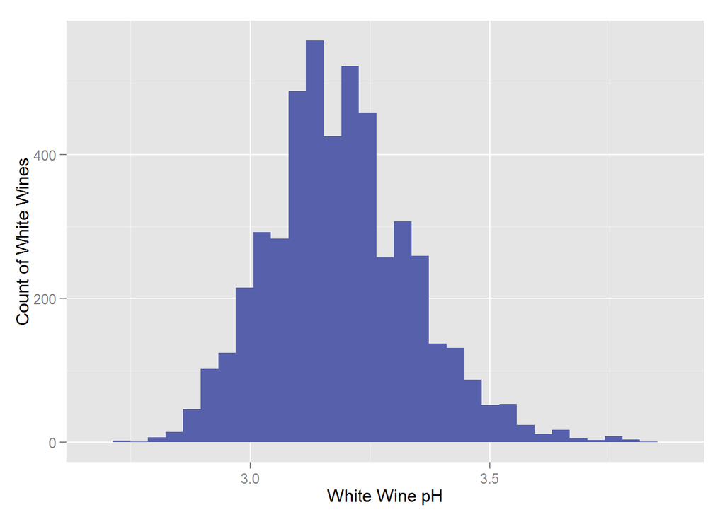

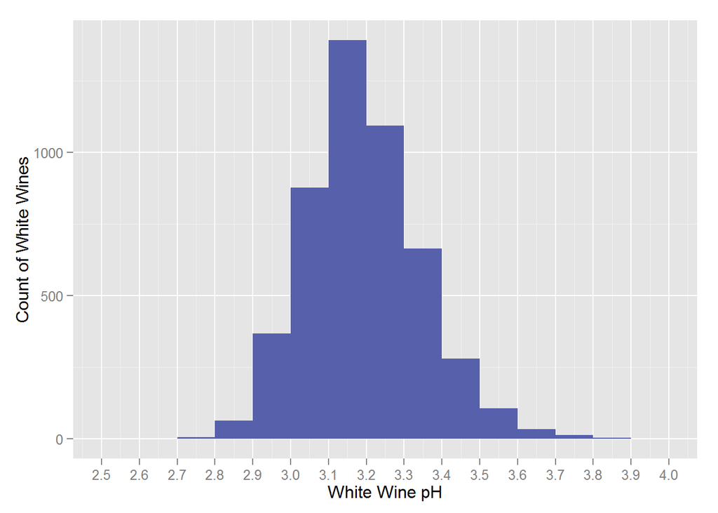

The pH plot indicates few outliers and providing the limits and breaks gives a better plot.

#### White Wine Sulphates (Table, summary by quality - plots)

```
##
## 0.22 0.23 0.25 0.26 0.27 0.28 0.29  0.3 0.31 0.32 0.33 0.34 0.35 0.36 0.37
##    1    1    4    4   13   13   16   31   35   54   59   84   85  120  129
## 0.38 0.39  0.4 0.41 0.42 0.43 0.44 0.45 0.46 0.47 0.48 0.49  0.5 0.51 0.52
##  214  151  168  139  181  161  216  178  225  172  179  166  249  140  156
## 0.53 0.54 0.55 0.56 0.57 0.58 0.59  0.6 0.61 0.62 0.63 0.64 0.65 0.66 0.67
##  135  167  102  108   83   99   97   88   45   68   48   67   28   36   35
## 0.68 0.69  0.7 0.71 0.72 0.73 0.74 0.75 0.76 0.77 0.78 0.79  0.8 0.81 0.82
##   44   30   27   18   33   12   19   22   19   16   19   16    5    5   13
## 0.83 0.84 0.85 0.86 0.87 0.88 0.89  0.9 0.92 0.94 0.95 0.96 0.97 0.98 0.99
##    2    4    3    2    2    7    1    5    2    2    5    3    1    6    1
##    1 1.01 1.06 1.08
##    1    1    1    1
```

```
## whiteWineQuality$quality: 3
##    Min. 1st Qu.  Median    Mean 3rd Qu.    Max.
##  0.2800  0.3800  0.4400  0.4745  0.5425  0.7400
## --------------------------------------------------------
## whiteWineQuality$quality: 4
##    Min. 1st Qu.  Median    Mean 3rd Qu.    Max.
##  0.2500  0.3800  0.4700  0.4761  0.5400  0.8700
## --------------------------------------------------------
## whiteWineQuality$quality: 5
##    Min. 1st Qu.  Median    Mean 3rd Qu.    Max.
##  0.2700  0.4200  0.4700  0.4822  0.5300  0.8800
## --------------------------------------------------------
## whiteWineQuality$quality: 6
##    Min. 1st Qu.  Median    Mean 3rd Qu.    Max.
##  0.2300  0.4100  0.4800  0.4911  0.5500  1.0600
## --------------------------------------------------------
## whiteWineQuality$quality: 7
##    Min. 1st Qu.  Median    Mean 3rd Qu.    Max.
##  0.2200  0.4100  0.4800  0.5031  0.5800  1.0800
## --------------------------------------------------------
## whiteWineQuality$quality: 8
##    Min. 1st Qu.  Median    Mean 3rd Qu.    Max.
##  0.2500  0.3800  0.4600  0.4862  0.5850  0.9500
## --------------------------------------------------------
## whiteWineQuality$quality: 9
##    Min. 1st Qu.  Median    Mean 3rd Qu.    Max.
##   0.360   0.420   0.460   0.466   0.480   0.610
```

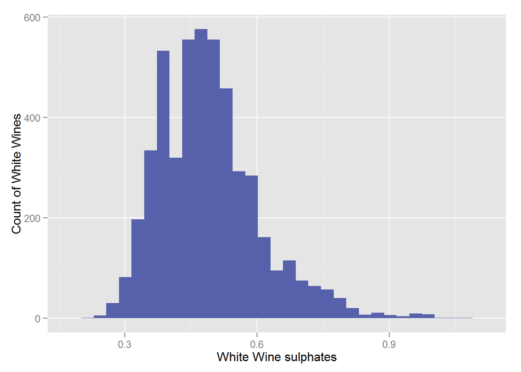

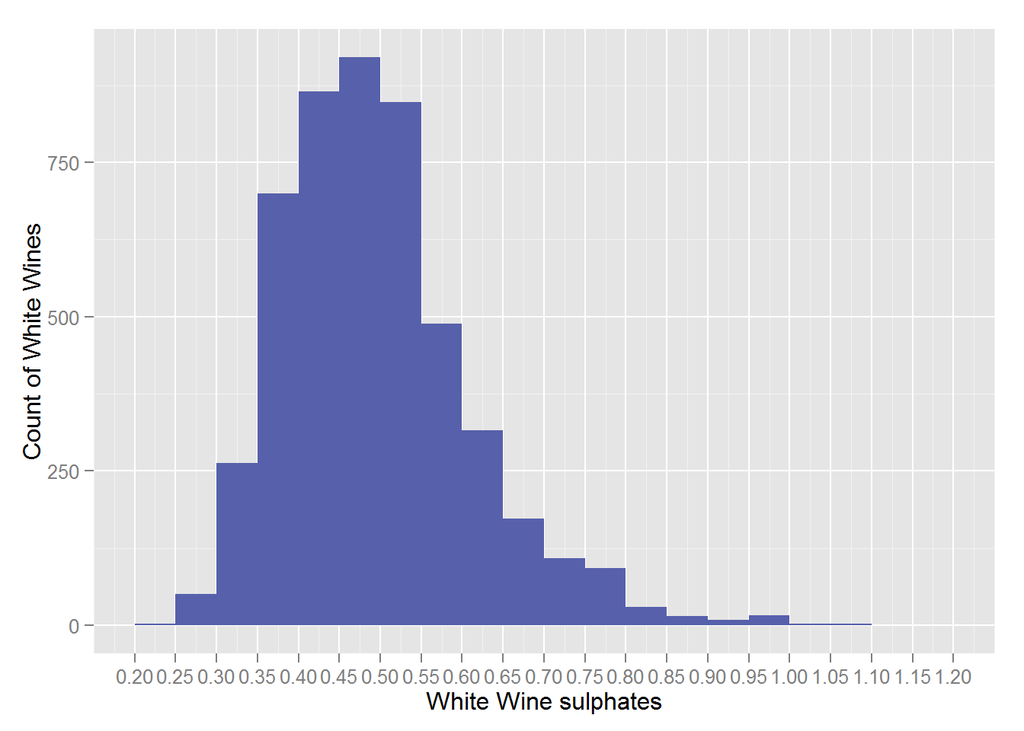

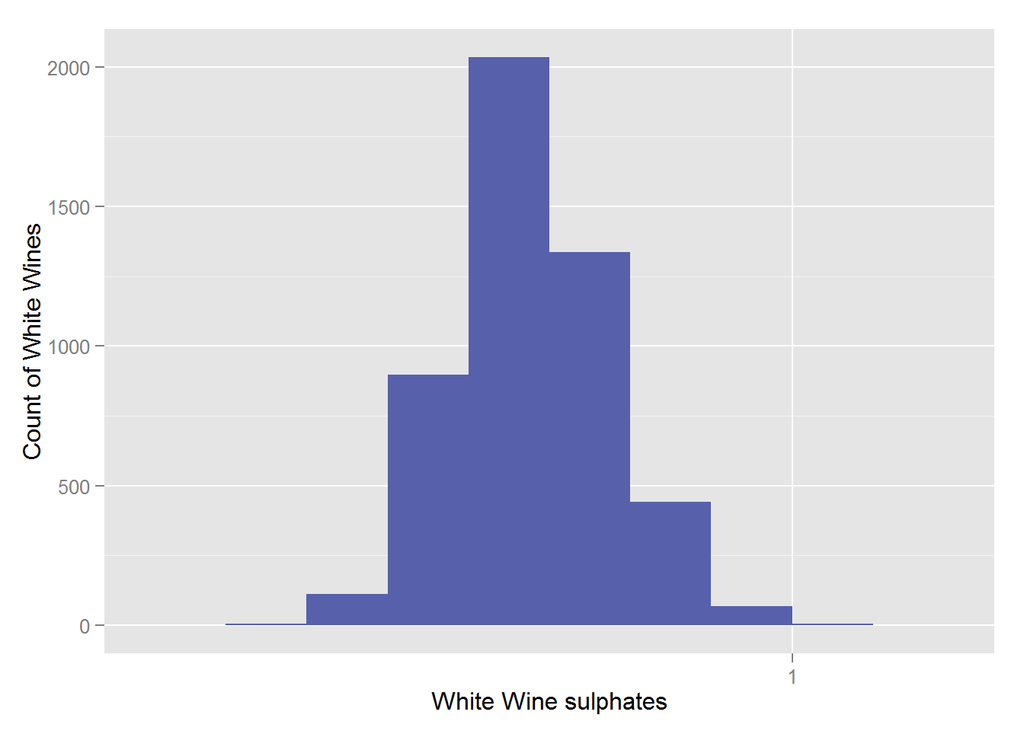

Sulphates is a right tailed plot and adding limits , breaks and binwidth confirms it. I add a log10 plot for this that would provide us a better plot for the sulphates content in this wine dataset.

#### White Wine Density (Table - summary by quality - plots)

[output not shown]

[output cut: 170 more lines]

[output not shown]

```
## whiteWineQuality$quality: 3
##    Min. 1st Qu.  Median    Mean 3rd Qu.    Max.
##  0.9911  0.9925  0.9944  0.9949  0.9969  1.0000
## --------------------------------------------------------
## whiteWineQuality$quality: 4
##    Min. 1st Qu.  Median    Mean 3rd Qu.    Max.
##  0.9892  0.9926  0.9941  0.9943  0.9958  1.0000
## --------------------------------------------------------
## whiteWineQuality$quality: 5
##    Min. 1st Qu.  Median    Mean 3rd Qu.    Max.
##  0.9872  0.9933  0.9953  0.9953  0.9972  1.0020
## --------------------------------------------------------
## whiteWineQuality$quality: 6
##    Min. 1st Qu.  Median    Mean 3rd Qu.    Max.
##  0.9876  0.9917  0.9937  0.9940  0.9959  1.0390
## --------------------------------------------------------
## whiteWineQuality$quality: 7
##    Min. 1st Qu.  Median    Mean 3rd Qu.    Max.
##  0.9871  0.9906  0.9918  0.9925  0.9937  1.0000
## --------------------------------------------------------
## whiteWineQuality$quality: 8
##    Min. 1st Qu.  Median    Mean 3rd Qu.    Max.
##  0.9871  0.9903  0.9916  0.9922  0.9935  1.0010
## --------------------------------------------------------
## whiteWineQuality$quality: 9
##    Min. 1st Qu.  Median    Mean 3rd Qu.    Max.
##  0.9896  0.9898  0.9903  0.9915  0.9906  0.9970
```

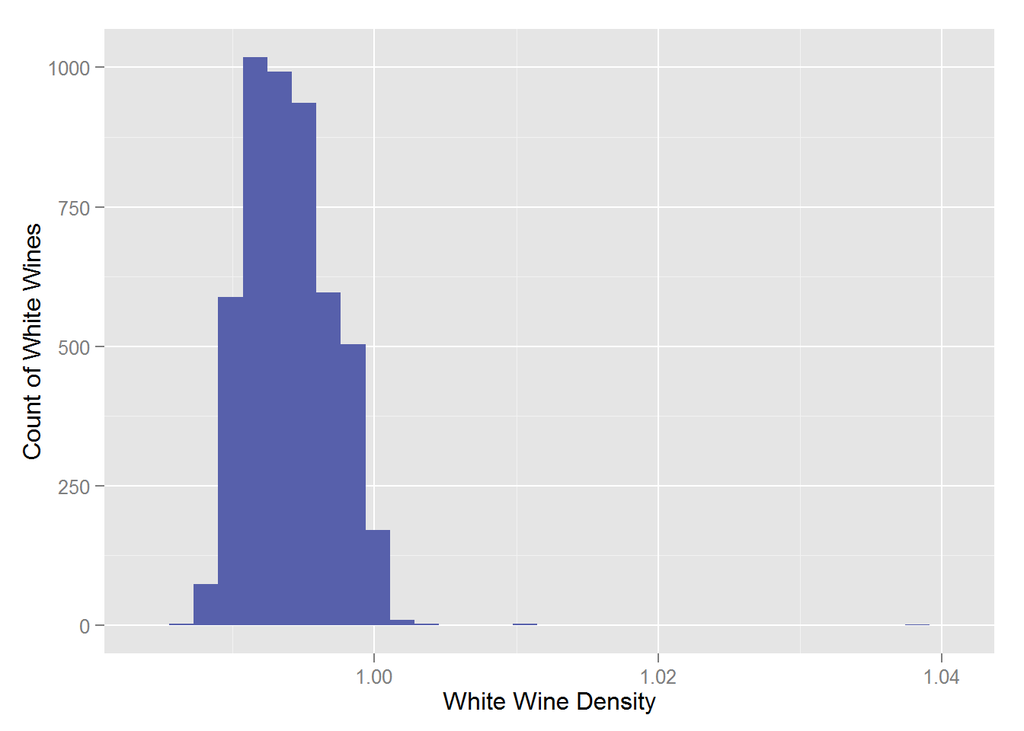

Most of the wine have very small variation in the density.

#### White Wine citric acid (Table - summary by quality - plots)

```
##
##    0 0.01 0.02 0.03 0.04 0.05 0.06 0.07 0.08 0.09  0.1 0.11 0.12 0.13 0.14
##   19    7    6    2   12    5    6   12    4   12   14    1   19   17   27
## 0.15 0.16 0.17 0.18 0.19  0.2 0.21 0.22 0.23 0.24 0.25 0.26 0.27 0.28 0.29
##   23   33   27   49   48   70   66  104   83  181  136  219  216  282  223
##  0.3 0.31 0.32 0.33 0.34 0.35 0.36 0.37 0.38 0.39  0.4 0.41 0.42 0.43 0.44
##  307  200  257  183  225  137  177  134  122  101  117   82   95   37   63
## 0.45 0.46 0.47 0.48 0.49  0.5 0.51 0.52 0.53 0.54 0.55 0.56 0.57 0.58 0.59
##   46   51   38   39  215   35   25   23   16   19   11   22   13   21    6
##  0.6 0.61 0.62 0.63 0.64 0.65 0.66 0.67 0.68 0.69  0.7 0.71 0.72 0.73 0.74
##    6    9   14    4    6    8    7    7    7    5    3    9    5    5   41
## 0.78 0.79  0.8 0.81 0.82 0.86 0.88 0.91 0.99    1 1.23 1.66
##    2    2    2    2    2    1    1    2    1    5    1    1
```

```
## whiteWineQuality$quality: 3
##    Min. 1st Qu.  Median    Mean 3rd Qu.    Max.
##  0.2100  0.2575  0.3450  0.3360  0.3850  0.4700
## --------------------------------------------------------
## whiteWineQuality$quality: 4
##    Min. 1st Qu.  Median    Mean 3rd Qu.    Max.
##  0.0000  0.1900  0.2900  0.3042  0.4000  0.8800
## --------------------------------------------------------
## whiteWineQuality$quality: 5
##    Min. 1st Qu.  Median    Mean 3rd Qu.    Max.
##  0.0000  0.2400  0.3200  0.3377  0.4100  1.0000
## --------------------------------------------------------
## whiteWineQuality$quality: 6
##    Min. 1st Qu.  Median    Mean 3rd Qu.    Max.
##   0.000   0.270   0.320   0.338   0.380   1.660
## --------------------------------------------------------
## whiteWineQuality$quality: 7
##    Min. 1st Qu.  Median    Mean 3rd Qu.    Max.
##  0.0100  0.2800  0.3100  0.3256  0.3600  0.7400
## --------------------------------------------------------
## whiteWineQuality$quality: 8
##    Min. 1st Qu.  Median    Mean 3rd Qu.    Max.
##  0.0400  0.2800  0.3200  0.3265  0.3600  0.7400
## --------------------------------------------------------
## whiteWineQuality$quality: 9
##    Min. 1st Qu.  Median    Mean 3rd Qu.    Max.
##   0.290   0.340   0.360   0.386   0.450   0.490
```

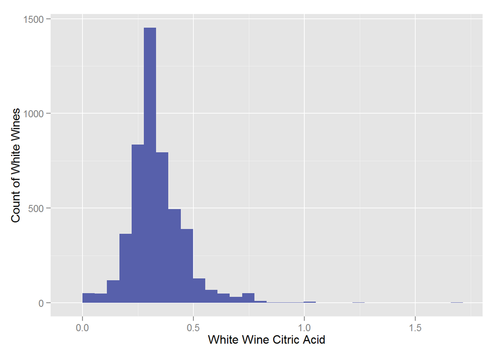

[figure not shown]

There isn’t much variance in the data for citric acid and is visible in the plot when appropriate binwidth and breaks are added.

# Univariate Analysis

### What is the structure of your dataset?

There are 4,898 white wines in the data set with 11 attribues. Most of the attributes contain information based on the physicochemical test performed on the wine which might influence the quality of wine. Observations: Quality of wine is the only ordered factor variable in this dataset. It ranges from 1-10 where 1 is the lowest quality and 10 is the highest quality. Most wine quality fall in midrange of 5-6. There are some attributes that have a big range while some don’t have much variance in them.

### What is/are the main feature(s) of interest in your dataset?

The main features in the data set is the quality of wine and and the chemicals present in them. I would like to find out if the variations in some variables in the wine impact the quality of the wine.

### What other features in the dataset do you think will help support your investigation into your feature(s) of interest?

Other features besides the chemical content I would like to find out if alcohol level, sugar residual, density and PH level also has any impact of the wine quality and the relationship between them. I tried to plot almost all the variables just to get familiar with the data and to decide which ones would I pick for further analysis.

### Did you create any new variables from existing variables in the dataset?

No I did not create any new variable for the data set.

### Of the features you investigated, were there any unusual distributions? Did you perform any operations on the data to tidy, adjust, or change the form of the data? If so, why did you do this?

I added binwidth and limit and breaks to all my plots to get a better plot to represent the data. I also added log10 plot for Sugar residual,sulphates and volatile acidity plot log10 to reduce the tail and give a better representation for the data.

# Bivariate Plots Section

#### Residual Sugar and Alcohol level

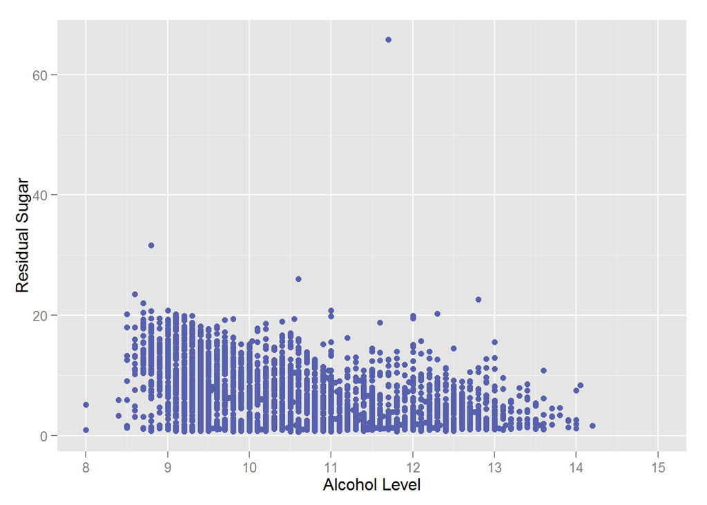

Comparing the relationship between residual sugar and alcohol level seems to indicate that lower alcohol level has more sugar residual.

#### pH level and Alcohol level

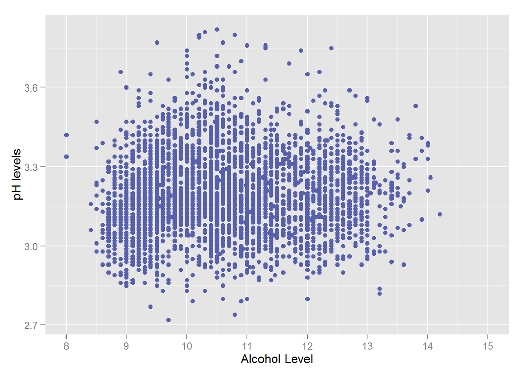

Comparing the relationship between pH levels and alcohol level. It seems to be consistent through out the all alcohol levels.

#### Density and Alcohol level

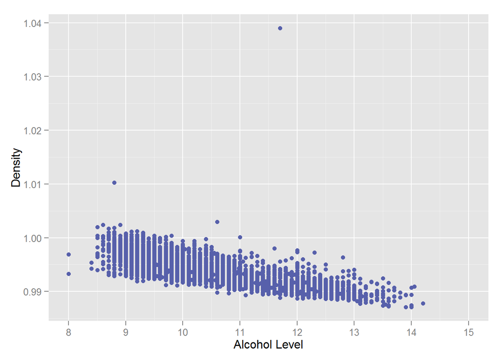

Comparing the relationship between Density and alcohol level. It seems to indicate that higher the alcohol content lower is the density.

#### volatile acidity and wine quality

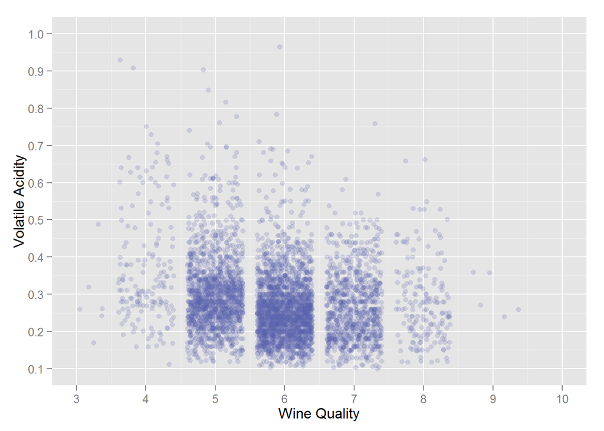

According to the plot most of the wine have the volatile acidity below 0.4.and none of the highest quality of 9 has volatile acidity higher than 0.4

#### Total and Free sulfur dioxide - plot

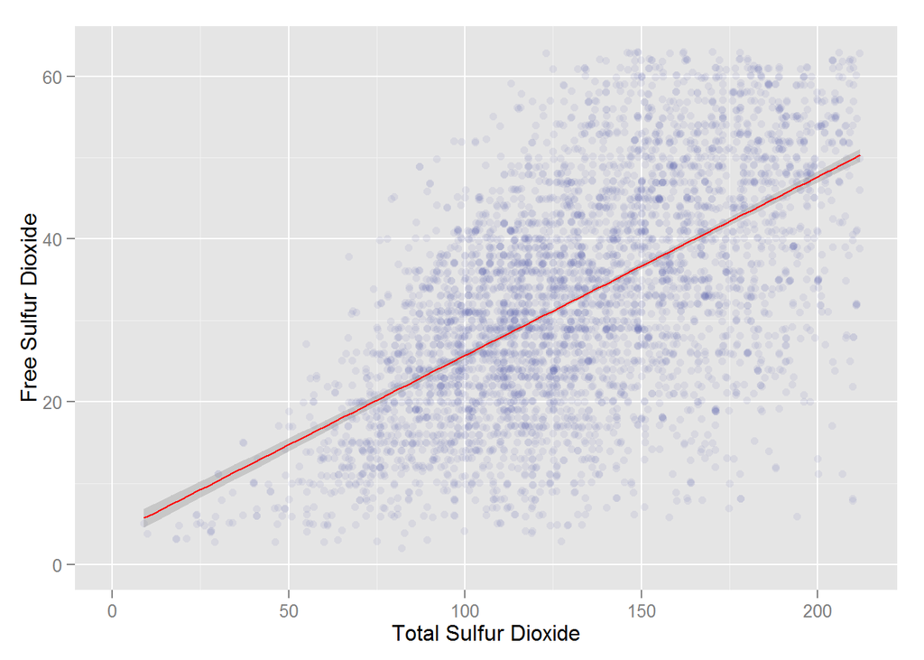

These 2 forms of SO2 have an almost linear relationship between the two variables.

#### Total and Free sulfur dioxide - correlation

```
##
##  Pearson's product-moment correlation
##
## data:  whiteWineQuality$total.sulfur.dioxide and whiteWineQuality$free.sulfur.dioxide
## t = 54.6447, df = 4896, p-value < 2.2e-16
## alternative hypothesis: true correlation is not equal to 0
## 95 percent confidence interval:
##  0.5977994 0.6326026
## sample estimates:
##      cor
## 0.615501
```

Since the correlation result is 0.616, there is a moderate relationship between the the 2 sulfur dioxide variables.

#### Sulphates and sulfur dioxide variables

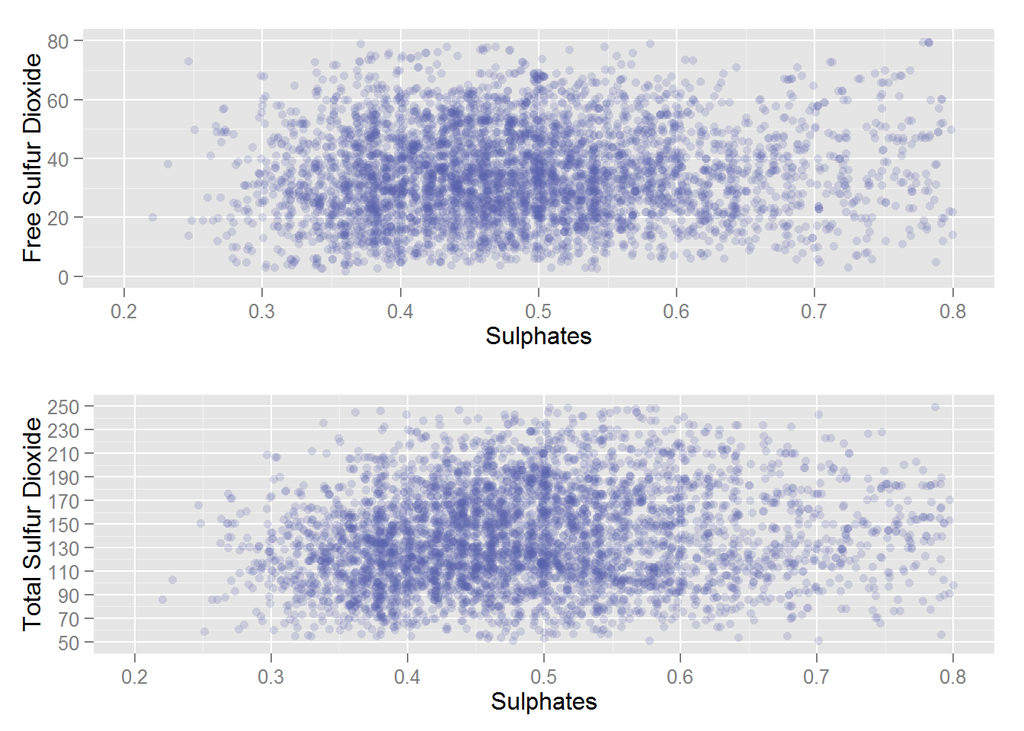

Relationship between Total Sulphur dioxide and sulphates and Free sulfur dioxide and sulphates is very similar when appropriate limits and breaks are added.

#### Wine Quality and Alcohol level - mean

```
## Source: local data frame [6 x 4]
##
##   quality alcohol_mean alcohol_median    n
## 1       3     10.34500          10.45   20
## 2       4     10.15245          10.10  163
## 3       5      9.80884           9.50 1457
## 4       6     10.57537          10.50 2198
## 5       7     11.36794          11.40  880
## 6       8     11.63600          12.00  175
```

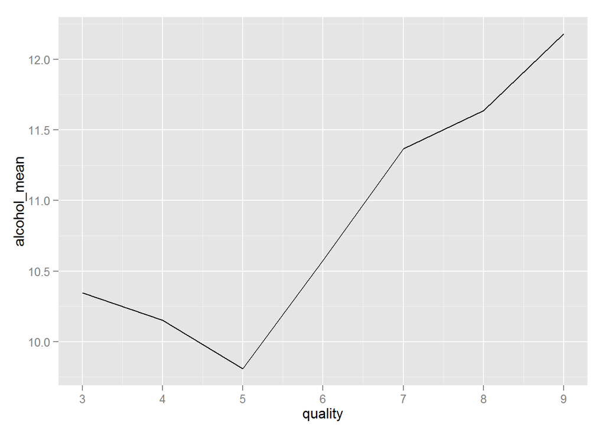

The plot indicates that the better quality white wines have higer alcohol levels.

#### Wine Quality and Alcohol level - boxplot, quantile

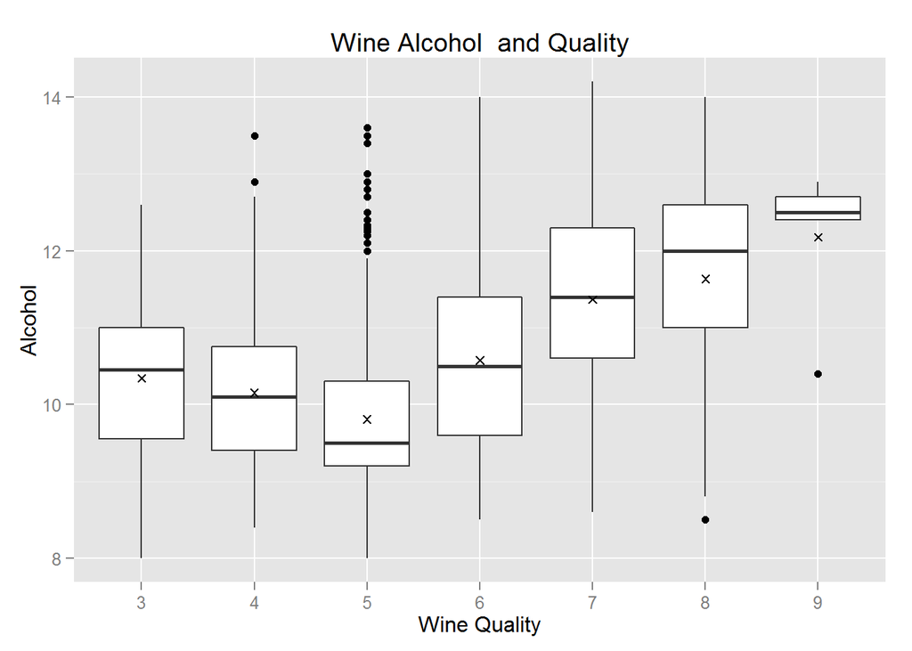

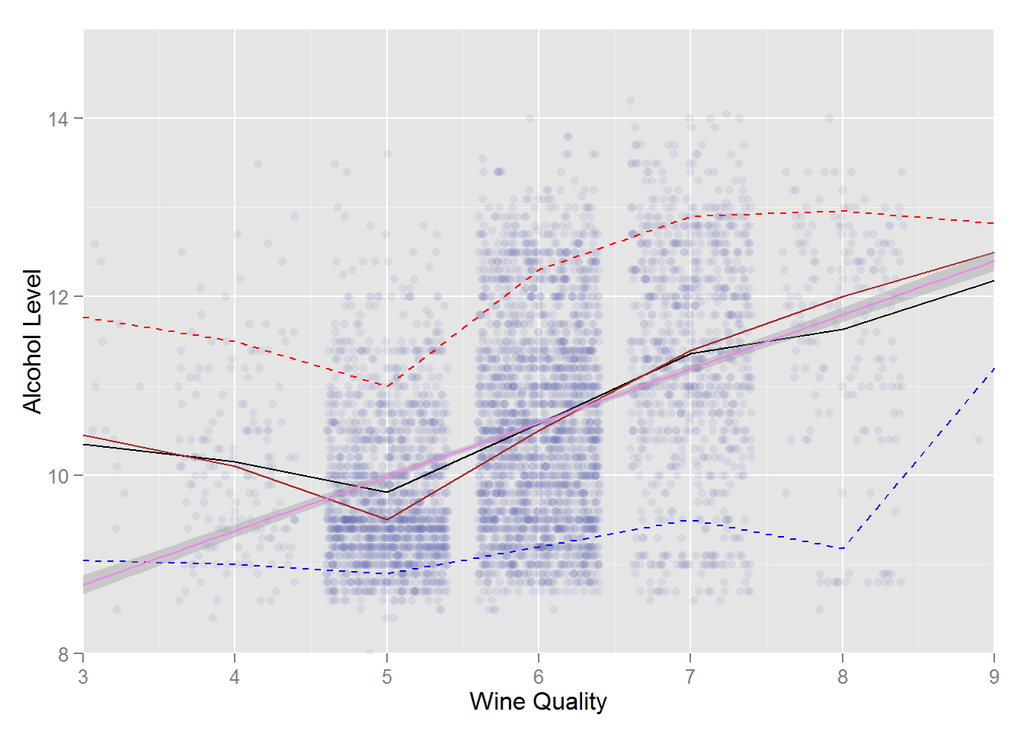

The plot provides the original scatter plot along with the mean , the 3 quantile and coord_cartesian lines.

#### Wine Quality and Alcohol level - Correlation

```
##
##  Pearson's product-moment correlation
##
## data:  whiteWineQuality$quality and whiteWineQuality$alcohol
## t = 33.8585, df = 4896, p-value < 2.2e-16
## alternative hypothesis: true correlation is not equal to 0
## 95 percent confidence interval:
##  0.4126015 0.4579941
## sample estimates:
##       cor
## 0.4355747
```

Since the correlation result is 0.436, there is some relationship between the alcohol level and wine quality.